# ST2195_Q2_Coursework_submission_Enriq_Mah

```python
import pandas as pd
import numpy as np
from scipy.stats import pearsonr
import glob
import math
import matplotlib.pyplot as plt
import matplotlib.ticker as ticker
import seaborn as sns
from sklearn.model_selection import train_test_split
import statsmodels.api as sm
```

## Reading the files and establishing data frames

```python
airports_df = pd.read_csv("airports.csv")
carriers_df = pd.read_csv("carriers.csv")
planes_df = pd.read_csv("plane-data.csv")
```

```python
manifest_df = pd.DataFrame()
for year in range(1990, 2000):
    file_pattern = f"{year}.csv"
    file_paths = glob.glob(file_pattern)
    year_data = pd.concat((pd.read_csv(file_path) for file_path in file_paths), ignore_index=True)
    #Cleaning the data
    year_data = year_data.drop_duplicates()
    year_data = year_data[(year_data['ActualElapsedTime'] >= 0) | (year_data['ActualElapsedTime'].isna())]
    year_data = year_data[(year_data['CRSElapsedTime'] >= 0) | (year_data['CRSElapsedTime'].isna())]
    year_data = year_data[(year_data['DepTime'] < 2400) | (year_data['DepTime'].isna())]
    year_data = year_data[(year_data['ArrTime'] < 2400) | (year_data['ArrTime'].isna())] #filters for times = 0 or na
    manifest_df = pd.concat([manifest_df, year_data], ignore_index=True)
#Dropping unused columns
manifest_df = manifest_df.drop(columns=['AirTime', 'CancellationCode', 'CarrierDelay', 'WeatherDelay', 'NASDelay', 'LateAircraftDelay', 'SecurityDelay', 'FlightNum', 'Origin', 'Dest', 'TaxiIn', 'TaxiOut', 'Cancelled'])

print(manifest_df.head())
```

```
   Year  Month  DayofMonth  DayOfWeek  DepTime  CRSDepTime  ArrTime  \
0  1990      1           3          3   1707.0        1630   1755.0
1  1990      1           4          4   1706.0        1630   1807.0
2  1990      1           5          5   1629.0        1630   1715.0
3  1990      1           6          6   1633.0        1630   1718.0
4  1990      1           8          1   1630.0        1630   1726.0

   CRSArrTime UniqueCarrier TailNum  ActualElapsedTime  CRSElapsedTime  \
0        1723            US     NaN               48.0            53.0
1        1723            US     NaN               61.0            53.0
2        1723            US     NaN               46.0            53.0
3        1723            US     NaN               45.0            53.0
4        1723            US     NaN               56.0            53.0

   ArrDelay  DepDelay  Distance  Diverted
0      32.0      37.0     182.0         0
1      44.0      36.0     182.0         0
2      -8.0      -1.0     182.0         0
3      -5.0       3.0     182.0         0
4       3.0       0.0     182.0         0
```

## Overview of the descriptive statistcis

Looking at the overall summary of the data, "ActualElapsedTime", "CRSElapsedTime" and "AirTime" should not be able to take negative numbers indicating that there is an error in the data. As such the rows with a negative value for "ActualElapsedTime"and "CRSElapsedTime" will be removed from the main data frame "manifest_df". "AirTime" will not be used in the analysis and this it is removed. "cancellationcode", "carrierdelay", "Weatherdelay", "SecurityDelay", "NASdelay" and "lateaircraftdelay" are only populated from 2003 to 2006, as such we do not have all 10 years to analyse and thus these rows will also be ommited.

The data is cleaned at an earlier stage to reduce memory load.

```python
print(manifest_df.info())
```

```
<class 'pandas.core.frame.DataFrame'>
RangeIndex: 52673426 entries, 0 to 52673425
Data columns (total 16 columns):
 #   Column             Dtype
---  ------             -----
 0   Year               int64
 1   Month              int64
 2   DayofMonth         int64
 3   DayOfWeek          int64
 4   DepTime            float64
 5   CRSDepTime         int64
 6   ArrTime            float64
 7   CRSArrTime         int64
 8   UniqueCarrier      object
 9   TailNum            object
 10  ActualElapsedTime  float64
 11  CRSElapsedTime     float64
 12  ArrDelay           float64
 13  DepDelay           float64
 14  Distance           float64
 15  Diverted           int64
dtypes: float64(7), int64(7), object(2)
memory usage: 6.3+ GB
None
```

```python
#Descriptive statistics of manifest_df
manifest_df.describe().apply(lambda x: x.apply(lambda y: '{:.0f}'.format(y) if isinstance(y, (int, float)) else y)).T
```

|  | count | mean | std | min | 25% | 50% | 75% | max |
| --- | --- | --- | --- | --- | --- | --- | --- | --- |
| Year | 52673426 | 1995 | 3 | 1990 | 1992 | 1995 | 1997 | 1999 |
| Month | 52673426 | 7 | 3 | 1 | 4 | 7 | 10 | 12 |
| DayofMonth | 52673426 | 16 | 9 | 1 | 8 | 16 | 23 | 31 |
| DayOfWeek | 52673426 | 4 | 2 | 1 | 2 | 4 | 6 | 7 |
| DepTime | 51781025 | 1351 | 477 | 1 | 934 | 1335 | 1739 | 2359 |
| CRSDepTime | 52673426 | 1327 | 489 | 0 | 923 | 1325 | 1728 | 2400 |
| ArrTime | 51655290 | 1496 | 495 | 1 | 1118 | 1524 | 1918 | 2359 |
| CRSArrTime | 52673426 | 1480 | 506 | 0 | 1110 | 1518 | 1913 | 2400 |
| ActualElapsedTime | 51655290 | 117 | 67 | 0 | 68 | 99 | 149 | 1883 |
| CRSElapsedTime | 52649304 | 118 | 66 | 0 | 70 | 100 | 149 | 1613 |
| ArrDelay | 51655290 | 7 | 27 | -1437 | -6 | 1 | 11 | 1808 |
| DepDelay | 51781025 | 8 | 26 | -1084 | -1 | 0 | 6 | 1800 |
| Distance | 52510608 | 691 | 536 | 11 | 307 | 533 | 929 | 4962 |
| Diverted | 52673426 | 0 | 0 | 0 | 0 | 0 | 0 | 1 |

## Classification and creation of new groupings

### What constitutes to a delay?

According to the United States Federal Aviation Administration (FAA), an aircraft is considered delayed when it is 15 minutes late than its scheduled time. Cancelled flights would classify as an anomaly and thus the data points with cancelled flights will be omitted in this particular analysis. The scheduled departure time is used as it is what travelers will be looking at when booking flights, thus, if we want to analyse delays and such we analyse form a traveler point of view.

**Degrees of Delay**  
With the above in consideration, a flight would be considered on time when it is 15 minutes from its scheduled time. A passenger would be entitled for compensations if the flight is delayed by more than 3 hours. The mild classification would be considered if the delay is under 1 hour and the delay would be considered moderate if the delay is under 3 hours. As such the relevant groupings of the degree of delay are as follows. (in minutes)

- Ontime <= 15
- Mild < 60
- Moderate < 180
- Major > 180

**Time of Day:**

- Midnight(0000-0559)
- Morning (0600-1159)
- Afternoon(1200-1759)
- Evening (1800-2359)

```python
# Function for grouping time into time of day
def group_time(time):
    hour = time // 100 #only takes in the first 2 digits of the time in HHMM
    if hour < 6:
        return "Midnight"
    elif hour < 12:
        return "Morning"
    elif hour < 18:
        return "Afternoon"
    else:
        return "Evening"

# Creates a new column called DepTimeOfDay and applying above function
manifest_df['DepTimeOfDay'] = manifest_df['CRSDepTime'].apply(group_time)

# Function for group delay
def group_delay(time):
    if pd.isna(time):
        return None
    elif time <= 15:
        return "Ontime"
    elif time < 60:
        return "Mild"
    elif time < 180:
        return "Moderate"
    else:
        return "Major"

# Creates a new column called DegreeOfDelay and applying above function
manifest_df['DegreeofDelay'] = manifest_df['ArrDelay'].apply(group_delay)

# Convert Days and Months to strings
days_order = ["Monday", "Tuesday", "Wednesday", "Thursday", "Friday", "Saturday", "Sunday"]
months_order = ["January", "February", "March", "April", "May", "June", "July", "August", "September", "October", "November", "December"]

manifest_df['DayOfWeekString'] = manifest_df['DayOfWeek'].apply(lambda day: days_order[day - 1]) #applies the lambda function which takes in dayofweek column and compares it to day order, -1 as python index starts from 0, therefore monday = 1 would be =0 in days_order
manifest_df['MonthString'] = manifest_df['Month'].apply(lambda month: months_order[month - 1]) #similar to above explaination but months

#Finalised main data frame
print(manifest_df.head())
```

```
   Year  Month  DayofMonth  DayOfWeek  DepTime  CRSDepTime  ArrTime  \
0  1990      1           3          3   1707.0        1630   1755.0
1  1990      1           4          4   1706.0        1630   1807.0
2  1990      1           5          5   1629.0        1630   1715.0
3  1990      1           6          6   1633.0        1630   1718.0
4  1990      1           8          1   1630.0        1630   1726.0

   CRSArrTime UniqueCarrier TailNum  ActualElapsedTime  CRSElapsedTime  \
0        1723            US     NaN               48.0            53.0
1        1723            US     NaN               61.0            53.0
2        1723            US     NaN               46.0            53.0
3        1723            US     NaN               45.0            53.0
4        1723            US     NaN               56.0            53.0

   ArrDelay  DepDelay  Distance  Diverted DepTimeOfDay DegreeofDelay  \
0      32.0      37.0     182.0         0    Afternoon          Mild
1      44.0      36.0     182.0         0    Afternoon          Mild
2      -8.0      -1.0     182.0         0    Afternoon        Ontime
3      -5.0       3.0     182.0         0    Afternoon        Ontime
4       3.0       0.0     182.0         0    Afternoon        Ontime

  DayOfWeekString MonthString
0       Wednesday     January
1        Thursday     January
2          Friday     January
3        Saturday     January
4          Monday     January
```

In "R", the DegreeofDelay was a not a string and had to be mutated, in Python, it is already a string.

```python
#Column names for report
column_names = manifest_df.columns.tolist()
print(column_names)
```

```
['Year', 'Month', 'DayofMonth', 'DayOfWeek', 'DepTime', 'CRSDepTime', 'ArrTime', 'CRSArrTime', 'UniqueCarrier', 'TailNum', 'ActualElapsedTime', 'CRSElapsedTime', 'ArrDelay', 'DepDelay', 'Distance', 'Diverted', 'DepTimeOfDay', 'DegreeofDelay', 'DayOfWeekString', 'MonthString']
```

## Part 2(a.i): When is the best time of day to fly to minimise delay?

For this portion we will consider the overall best time and best time for each year from 1990 to 1999

**Creating Data Frames to answer the question**

```python
# Data frame for overall best time
time_of_day_df = manifest_df.dropna(subset=['DegreeofDelay']) # Filters out the empty and 'na' cells
time_of_day_df = time_of_day_df.groupby(['DepTimeOfDay', 'DegreeofDelay']).size().reset_index(name='count') # Count for each degree of delay
# Calculates weighted percentage and rounds to 2dp
time_of_day_df["WeightedPercentage"] = (time_of_day_df['count'] / time_of_day_df.groupby('DepTimeOfDay')['count'].transform('sum')) * 100
time_of_day_df['WeightedPercentage'] = time_of_day_df['WeightedPercentage'].round(2)

print(time_of_day_df.head())
```

```
  DepTimeOfDay DegreeofDelay     count  WeightedPercentage
0    Afternoon         Major     73997                0.38
1    Afternoon          Mild   3076425               15.74
2    Afternoon      Moderate    739309                3.78
3    Afternoon        Ontime  15652367               80.10
4      Evening         Major     56069                0.50
```

The average delay is calculated for each year by the time of day and plotted for each year

```python
#data frame for each year
tod_year_df = manifest_df.groupby(['Year', 'DepTimeOfDay'])['ArrDelay'].mean().reset_index()
tod_year_df = tod_year_df.rename(columns={'ArrDelay': 'AverageArrDelay'})
print(tod_year_df.head())
```

```
   Year DepTimeOfDay  AverageArrDelay
0  1990    Afternoon         7.516771
1  1990      Evening         9.745566
2  1990     Midnight         3.261771
3  1990      Morning         4.384826
4  1991    Afternoon         5.540226
```

**Graph for visualisation**

```
Axes(0.125,0.11;0.775x0.77)
```

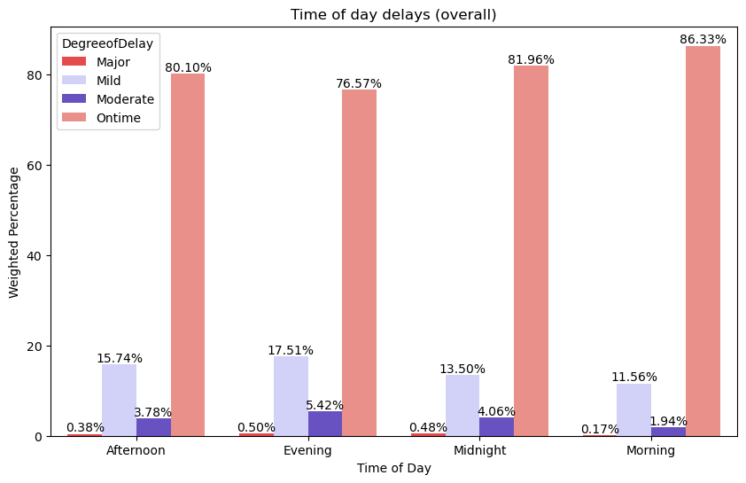

```python
color_selection = ["#FF3131", "#CCCCFF", "#5D3FD3", "#F88379"] # colour palate

plt.figure(figsize=(10, 6))
tod_overall_g = sns.barplot(data=time_of_day_df,
                            x='DepTimeOfDay',
                            y='WeightedPercentage',
                            hue='DegreeofDelay',
                            palette=color_selection,
                            dodge=True,) #dodge to unstack bar

# percentage labels for each bar and legend
for b in tod_overall_g.patches:
    tod_overall_g.annotate(
        f'{b.get_height():.2f}%', # indicates the text anotations and the format being a string with 2 decimal places and % attached to the string
        (b.get_x() + b.get_width() / 2., b.get_height()),
        ha='center',
        va='center',
        xytext=(0, 5),
        textcoords='offset points',
        size=10,)

# labels and title
plt.title("Time of day delays (overall)")
plt.xlabel("Time of Day")
plt.ylabel("Weighted Percentage")
print(tod_overall_g)
```

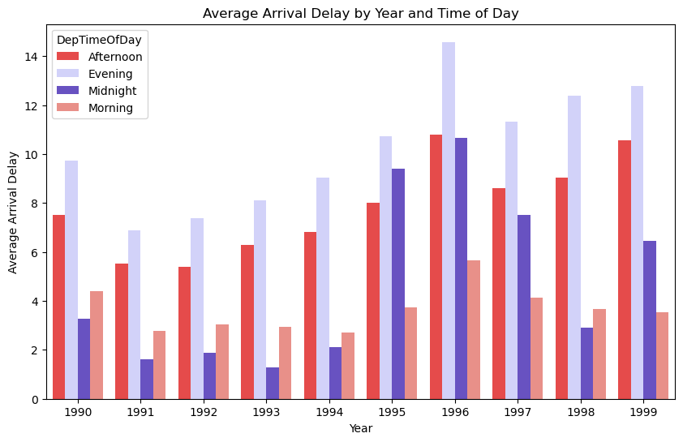

```python
plt.figure(figsize=(10, 6))
sns.barplot(data=tod_year_df,
            x='Year',
            y='AverageArrDelay',
            hue='DepTimeOfDay',
            palette=color_selection,
            dodge=True,)

# Set plot labels and title
plt.title("Average Arrival Delay by Year and Time of Day")
plt.xlabel("Year")
plt.ylabel("Average Arrival Delay")

plt.show()
```

**Answer to question: When is the best time of day to fly to minimize delay?**

```python
# selects only ontime
ontime_df = time_of_day_df[time_of_day_df['DegreeofDelay'] == "Ontime"]
ontime_df = ontime_df.sort_values(by='WeightedPercentage', ascending=False)

best_time_of_day = ontime_df.iloc[0]['DepTimeOfDay']
weighted_percentage_delay = 100 - ontime_df.iloc[0]['WeightedPercentage']

print(f"The best time of day to travel to minimize delays is in the {best_time_of_day.lower()} with a weighted percentage delay of {weighted_percentage_delay:.2f}%")
```

```
The best time of day to travel to minimize delays is in the morning with a weighted percentage delay of 13.67%
```

```python
lowest_delay_by_year_df = tod_year_df.loc[tod_year_df.groupby('Year')['AverageArrDelay'].idxmin()] #retreives the lowest average arrival delay for each year

# for loop to print best time to travel each year
for year in lowest_delay_by_year_df['Year'].unique():
    year_data = lowest_delay_by_year_df[lowest_delay_by_year_df['Year'] == year]
    best_time_of_day = year_data.iloc[0]['DepTimeOfDay']
    print(f"For {year}, the best time of day to travel is {best_time_of_day}")
```

```
For 1990, the best time of day to travel is Midnight
For 1991, the best time of day to travel is Midnight
For 1992, the best time of day to travel is Midnight
For 1993, the best time of day to travel is Midnight
For 1994, the best time of day to travel is Midnight
For 1995, the best time of day to travel is Morning
For 1996, the best time of day to travel is Morning
For 1997, the best time of day to travel is Morning
For 1998, the best time of day to travel is Midnight
For 1999, the best time of day to travel is Morning
```

The worst time to fly is in the evening, as it has the highest weighted percentage for major delays and lowest weighted percentage for flights that are on time. Across the decade, the average delays in the evening is also the highest while mornings and midnights tend to have lower average delays.

## Part 2(a.ii): When is the best day of the week to fly to minimise delay?

The definition of delays for this part is the same as the definition for delay in Part 2(a.i), the approach to quantifying the delays for each day of the week for each year will be taking the mean arrival delay, similar to question 2(a.i).

**Creating Data Frames**

```python
# Overall data
day_of_week_df = manifest_df.dropna(subset=['DayOfWeekString', 'DegreeofDelay'])
day_of_week_df = day_of_week_df[day_of_week_df['DegreeofDelay'] != ""]

day_of_week_df = day_of_week_df.groupby(['DayOfWeekString', 'DegreeofDelay']).size().reset_index(name='n')
day_of_week_df['WeightedPercentage'] = round((day_of_week_df['n'] / day_of_week_df.groupby('DayOfWeekString')['n'].transform('sum')) * 100, 2)

day_order = ["Monday", "Tuesday", "Wednesday", "Thursday", "Friday", "Saturday", "Sunday"]
day_of_week_df['DayOfWeek'] = pd.Categorical(day_of_week_df['DayOfWeekString'], categories=day_order, ordered=True) #ensures that the graph plots in day order

print(day_of_week_df.head())
```

```
  DayOfWeekString DegreeofDelay        n  WeightedPercentage DayOfWeek
0          Friday         Major    33491                0.45    Friday
1          Friday          Mild  1277355               16.98    Friday
2          Friday      Moderate   326392                4.34    Friday
3          Friday        Ontime  5886084               78.24    Friday
4          Monday         Major    21779                0.29    Monday
```

```python
# data frame for each year
dow_year_df = manifest_df.groupby(['Year', 'DayOfWeekString'])['ArrDelay'].mean().reset_index(name='AverageArrDelay')
day_order = ["Monday", "Tuesday", "Wednesday", "Thursday", "Friday", "Saturday", "Sunday"]
dow_year_df['DayOfWeekString'] = pd.Categorical(dow_year_df['DayOfWeekString'], categories=day_order, ordered=True) #day_order defined in chunk above

print(dow_year_df.head())
```

```
   Year DayOfWeekString  AverageArrDelay
0  1990          Friday        11.156782
1  1990          Monday         4.819963
2  1990        Saturday         5.238032
3  1990          Sunday         4.959252
4  1990        Thursday         9.958573
```

**Plotting the graph for visualisation**

```
Axes(0.125,0.11;0.775x0.77)
```

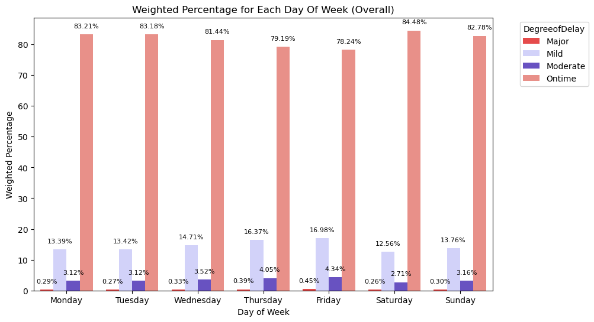

```python
#graph for overall best day
#colour selecton defined above
plt.figure(figsize=(10, 6))
dow_overall_g = sns.barplot(data=day_of_week_df,
                            x='DayOfWeek',
                            y='WeightedPercentage',
                            hue='DegreeofDelay',
                            palette=color_selection,
                            dodge=True,)

# percentage labels for each bar and legend
for b in dow_overall_g.patches:
    dow_overall_g.annotate(
        f'{b.get_height():.2f}%',
        (b.get_x() + b.get_width() / 2., b.get_height()),
        ha='center',
        va='center',
        xytext=(0, 10),
        textcoords='offset points',
        size=8,)

# labels, title and legend
plt.title("Weighted Percentage for Each Day Of Week (Overall)")
plt.xlabel("Day of Week")
plt.ylabel("Weighted Percentage")
plt.legend(title='DegreeofDelay', bbox_to_anchor=(1.05, 1), loc='upper left') #bbox_to_anchor=(1.05, 1) moves the legend outsdie the graph as there is no space

print(dow_overall_g)
```

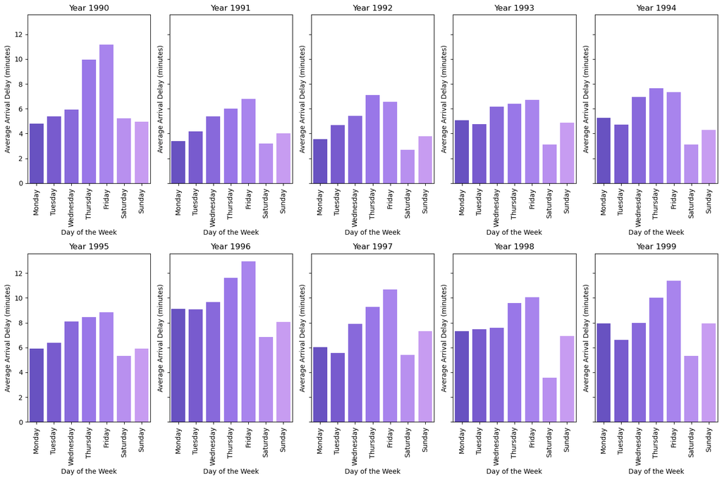

```python
color_selection = ["#5D3FD3", "#6E48E1", "#7F56EE", "#9164FB", "#A372FF", "#B580FF", "#C78EFF"] # colour palate

#graph for yearly best day
fig, axes = plt.subplots(2, 5, figsize=(15, 10), sharey=True) #defines a 2x5 grid to plot 10 graphs in one output
axes = axes.flatten() #Flatten to 2d array to let for loop iterate and plot graph

for i, (year, data) in enumerate(dow_year_df.groupby('Year')):
    # Determine where the subplot is plotted
    row_index = i // 5
    col_index = i % 5

    # Plot the bar graph for the current year, i
    sns.barplot(x='DayOfWeekString', y='AverageArrDelay', data=data, ax=axes[i], palette=color_selection)

    # Title and labels
    axes[i].set_title(f'Year {year}')
    axes[i].set_xlabel('Day of the Week')
    axes[i].set_ylabel('Average Arrival Delay (minutes)')
    axes[i].tick_params(axis='x', rotation=90)  # Rotate x-axis labels for better visibility

# adjusting for fitting of graph
plt.tight_layout()
plt.show()
```

**Answer to question: When is the best day of the week to fly to minimize delay?**

```python
# preparing the overall data frame to print
ontime_df = day_of_week_df[day_of_week_df['DegreeofDelay'] == "Ontime"]
ontime_df = ontime_df.sort_values(by='WeightedPercentage', ascending=False)
best_day_of_week = ontime_df.iloc[0]['DayOfWeekString']
weighted_percentage_delay = 100 - ontime_df.iloc[0]['WeightedPercentage']

print(f"The best day of the week to travel to minimize delays is on {best_day_of_week.lower()} with a weighted percentage delay of {weighted_percentage_delay:.2f}%")
```

```
The best day of the week to travel to minimize delays is on saturday with a weighted percentage delay of 15.52%
```

```python
# Creating data frame for minimum average delay per year
lowest_delay_dow_year_df = dow_year_df.loc[dow_year_df.groupby('Year')['AverageArrDelay'].idxmin()]

# loops through every year and print the best day to travel
for year in lowest_delay_dow_year_df['Year'].unique():
    year_df = lowest_delay_dow_year_df[lowest_delay_dow_year_df['Year'] == year]
    best_day_of_week_df = year_df.iloc[0]['DayOfWeekString']
    print(f"For {year}, the best day to travel is {best_day_of_week_df}")
```

```
For 1990, the best day to travel is Monday
For 1991, the best day to travel is Saturday
For 1992, the best day to travel is Saturday
For 1993, the best day to travel is Saturday
For 1994, the best day to travel is Saturday
For 1995, the best day to travel is Saturday
For 1996, the best day to travel is Saturday
For 1997, the best day to travel is Saturday
For 1998, the best day to travel is Saturday
For 1999, the best day to travel is Saturday
```

The worst time to fly is on Thursdays and Fridays, as it has the two days have the highest weighted percentage for major delays and lowest weighted percentage for flights that are on time. Across the decade, the average delays on the 2 days are also the highest while saturdays tend to have lower average delays.

## Part 2 (b). Evaluate whether older planes suffer more delays on a year-to-year basis

In this analysis, the delay is not specified, thus both arrival and departure delays are analysed. To make the analysis simple, we will look at the average delays. A plane would be considered old when it is more than 20 years old. We will be performing a correlation analysis on age of plane and delays.

It is important to note that tail number for years 1990 to 1994 is not available and thus cannot be used for this analysis as there is no other way to merge and identify the plane.

Classification of correlations, in absolute values:  
Perfect Correlation (1)  
Strong Correlation (0.7 to 0.99)  
Moderate Correlation (0.5 to 0.69)  
Weak Correlation (0.3 to 0.49)  
No Correlation (0 to 0.29)

This analysis will look at the overall delays and also on a year to year basis.

**Creating the data frame for delays**

```python
# cleaning the planes data
planes_df['year'] = pd.to_numeric(planes_df['year'], errors = 'coerce')  #ensures that all the different forms of null is converted into "null"
print(str(planes_df))
```

```
     tailnum                 type                   manufacturer  issue_date  \
0     N050AA                  NaN                            NaN         NaN
1     N051AA                  NaN                            NaN         NaN
2     N052AA                  NaN                            NaN         NaN
3     N054AA                  NaN                            NaN         NaN
4     N055AA                  NaN                            NaN         NaN
...      ...                  ...                            ...         ...
5024  N997DL          Corporation  MCDONNELL DOUGLAS AIRCRAFT CO   3/11/1992
5025  N998AT          Corporation                         BOEING  01/23/2003
5026  N998DL          Corporation  MCDONNELL DOUGLAS CORPORATION    4/2/1992
5027  N999CA  Foreign Corporation                       CANADAIR    7/9/2008
5028  N999DN          Corporation  MCDONNELL DOUGLAS CORPORATION    4/2/1992

            model status            aircraft_type engine_type    year
0             NaN    NaN                      NaN         NaN     NaN
1             NaN    NaN                      NaN         NaN     NaN
2             NaN    NaN                      NaN         NaN     NaN
3             NaN    NaN                      NaN         NaN     NaN
4             NaN    NaN                      NaN         NaN     NaN
...           ...    ...                      ...         ...     ...
5024        MD-88  Valid  Fixed Wing Multi-Engine   Turbo-Fan  1992.0
5025      717-200  Valid  Fixed Wing Multi-Engine   Turbo-Fan  2002.0
5026        MD-88  Valid  Fixed Wing Multi-Engine   Turbo-Jet  1992.0
5027  CL-600-2B19  Valid  Fixed Wing Multi-Engine   Turbo-Jet  1998.0
5028        MD-88  Valid  Fixed Wing Multi-Engine   Turbo-Jet  1992.0

[5029 rows x 9 columns]
```

```python
# Data frame for age of planes and delays for every year
# Joins both data frames by the tailnumber and finds average delay grouped by age
manifest_df.columns = manifest_df.columns.str.lower()
planes_df.columns = planes_df.columns.str.lower() #reduce confusion of which variables are from which data frame by making everything in lower case
# Merging the 2 data frames on tailnum
# This is where 1990 to 1994 data cannot be joined
delay_planes_df = pd.merge(manifest_df, planes_df, how='inner', left_on='tailnum', right_on='tailnum', suffixes=('_manifest_df', '_planes_df'))

delay_planes_df = delay_planes_df[delay_planes_df['year_planes_df'] != 0] #since some null years data = 0 this takes care of those rows

delay_planes_df = delay_planes_df.rename(columns={'year_manifest_df': 'YearOfFlight', 'year_planes_df': 'YearOfManufacture'})
delay_planes_df['AgeOfPlane'] = delay_planes_df['YearOfFlight'] - delay_planes_df['YearOfManufacture']

delay_planes_df = delay_planes_df[(delay_planes_df['AgeOfPlane'].notna()) & (delay_planes_df['AgeOfPlane'] >= 0)]

delay_planes_df = delay_planes_df.groupby(['YearOfFlight', 'AgeOfPlane']).agg(
    AverageArrDelay=('arrdelay', 'mean'),
    CountArrDelay=('arrdelay', 'count'),
    AverageDepDelay=('depdelay', 'mean'),
    CountDepDelay=('depdelay', 'count')
).reset_index() #applies the mean and standard deviation functions to the columns

print(delay_planes_df.head())
```

```
   YearOfFlight  AgeOfPlane  AverageArrDelay  CountArrDelay  AverageDepDelay  \
0          1995         0.0         7.042028          31741         8.492610
1          1995         1.0         5.745978          77639         6.993690
2          1995         2.0         6.798156          70505         8.277701
3          1995         3.0         6.292899         176856         7.926429
4          1995         4.0         7.175872         184458         8.514828

   CountDepDelay
0          31800
1          77817
2          70648
3         177204
4         184749
```

```python
#Data frame for each year split into a list of 5 data frames
delay_planes_yearly_df = dict(tuple(delay_planes_df.groupby('YearOfFlight')))
```

**Answer to the question: Do older planes suffer more delays?**

**Overall correlation**  
We want to first have an initial visual representation of the relationship between the age of planes, average departure delay and average arrival delay

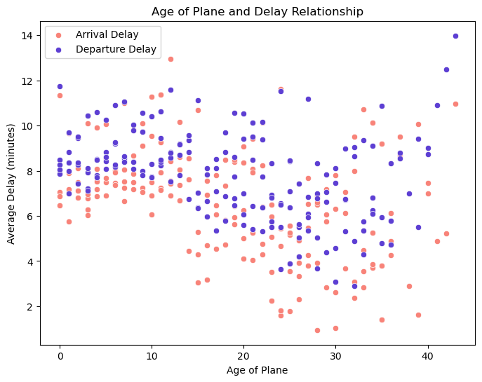

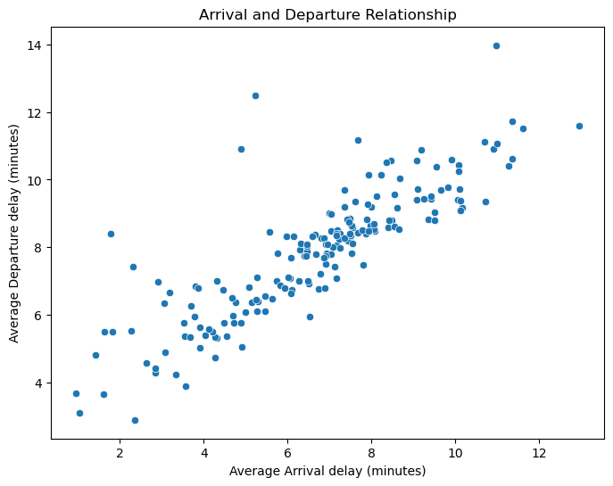

```python
# Graph for visualization
# Overlay both departure and arrival delays for comparison
fig, ax = plt.subplots(figsize=(8, 6))

# Average Arrival Delay
sns.scatterplot(data=delay_planes_df, x='AgeOfPlane', y='AverageArrDelay', color='#F88379', label='Arrival Delay', ax=ax)

# Average Departure Delay
sns.scatterplot(data=delay_planes_df, x='AgeOfPlane', y='AverageDepDelay', color='#5D3FD3', label='Departure Delay', ax=ax)
# Both plots are plotted on the same axis

# Set title, labels and legend
ax.set_title("Age of Plane and Delay Relationship")
ax.set_xlabel("Age of Plane")
ax.set_ylabel("Average Delay (minutes)")
ax.legend()

plt.show()

# Plotting Average Arrival Delay vs. Average Departure Delay
plt.figure(figsize=(8, 6))
sns.scatterplot(data=delay_planes_df, x='AverageArrDelay', y='AverageDepDelay')
plt.title("Arrival and Departure Relationship")
plt.xlabel("Average Arrival delay (minutes)")
plt.ylabel("Average Departure delay (minutes)")
plt.show()
```

It can be implied from the 2 plots that the age of plane seems to have a weak negative linear correlation on average arrival and delay (in minutes). While the average arrival and delay has a strong positive linear correlation. We now want to test the pearson correlation to have statistical values and create a correlation plot between the 3 variables.

```python
#correlation test between age of plane and arrival delay/departure delay (overall)
correlation_age_arrival, _ = pearsonr(delay_planes_df['AgeOfPlane'], delay_planes_df['AverageArrDelay'])
print(f"Pearson Correlation between Age of Plane and Average Arrival Delay: {correlation_age_arrival:.4f}")
correlation_age_departure, _ = pearsonr(delay_planes_df['AgeOfPlane'], delay_planes_df['AverageDepDelay'])
print(f"Pearson Correlation between Age of Plane and Average Departure Delay: {correlation_age_departure:.4f}")
correlation_arrival_departure, _ = pearsonr(delay_planes_df['AverageArrDelay'], delay_planes_df['AverageDepDelay'])
print(f"Pearson Correlation between Average Arrival Delay and Average Departure Delay: {correlation_arrival_departure:.4f}")
```

```
Pearson Correlation between Age of Plane and Average Arrival Delay: -0.4044
Pearson Correlation between Age of Plane and Average Departure Delay: -0.3141
Pearson Correlation between Average Arrival Delay and Average Departure Delay: 0.8530
```

**Correlation plot**

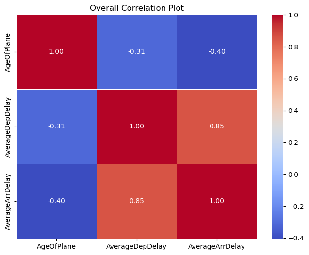

```python
# Creating correlation matrix
delay_planes_corr_df = delay_planes_df[['AgeOfPlane', 'AverageDepDelay', 'AverageArrDelay']]
correlation_matrix = delay_planes_corr_df.corr()

# Plotting the correlation matrix
plt.figure(figsize=(8, 6))
sns.heatmap(correlation_matrix, annot=True, cmap='coolwarm', fmt='.2f', linewidths=0.5, annot_kws={"size": 10})
plt.title("Overall Correlation Plot")
plt.show()
```

As per our visual inspection, the overall correlation of age of plane with average departure delay and average arrival delay are both weak negative linear correlations. The average arrival delays do have a slightly higher correlation with the age of a plane compared to the average departure delays.

**Individual year correlations**  
For the individual years, only the correlation plot will be plotted as it is the most effective and compact way to visualise all the correlation coefficients across every year.

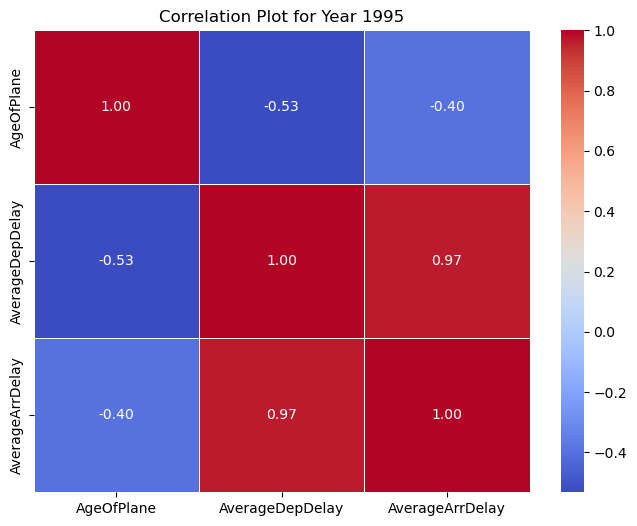

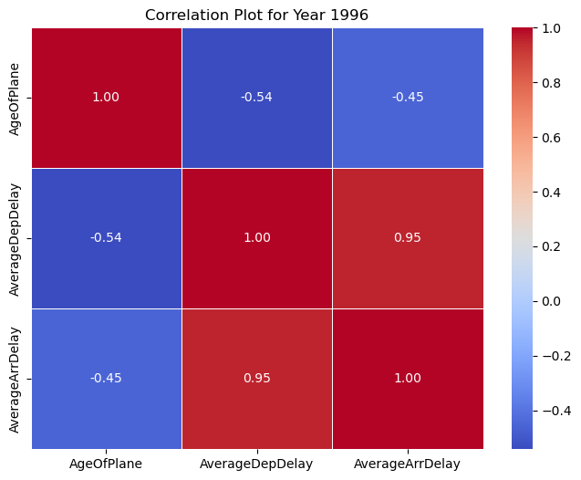

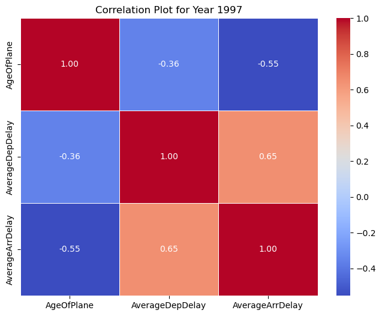

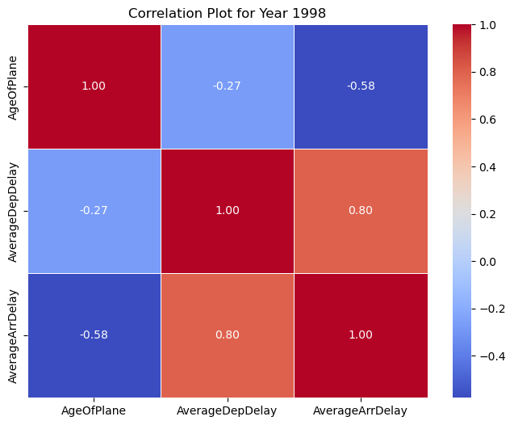

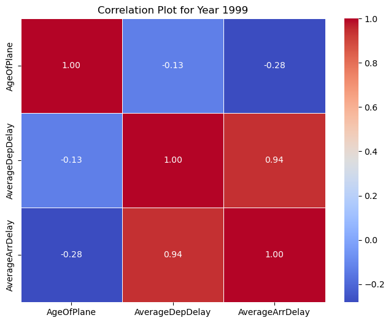

```python
# Iterate through each year's data frame
for year, current_yearly_delay_df in delay_planes_yearly_df.items():
    corr_var = current_yearly_delay_df[["AgeOfPlane", "AverageDepDelay", "AverageArrDelay"]] #the correlation variables desired
    correlation_matrix = corr_var.corr()

    # Plotting the correlation matrix
    plt.figure(figsize=(8, 6))
    sns.heatmap(correlation_matrix, annot=True, cmap='coolwarm', fmt='.2f', linewidths=0.5)
    plt.title(f"Correlation Plot for Year {year}")
    plt.show()
```

Across the 5 years, we see that there is a negative correlation between the age of planes and the average delays for both departure and arrivals. For years 1995 and 1996, there is a moderate negative linear correlation with age of plane and average departure delay while there is a weak negative linear correlation with age of plane and average arrival delay. For years 1997 and 1998, there is a moderate negative linear correlation with age of plane and average arrival delay. For 1997 there is a weak negative linear correlation with age of plane and average departure delay while 1998 has no correlation between age of plane and average departure delay. In 1999, there is no correlation between age of planes and average delays for both departure and arrivals.

In general, the age of a plane has weak negative linear correlation with delays. However, it seems that older planes suffer from less delays than newer planes. However, older planes seem to be more inconsistent than younger planes. This may be due to the reliability of older planes using tired and tested parts while some new planes be using experimental parts, while this cannot be confirmed statistically it may be a factor as to why older planes have less delays than newer planes.

## Part 2 (c) Logistic regression

In this part, the visualisation of the probabilities will be plotted with a dot plot where the fitted values(predicted probabilities of each flight) will be plotted against each independent variable. The mean fitted values for each year will then be plotted across the years to see how the probability of diverted flights change across the years. Finally, a logistic regression will be done for each year to get the yearly coefficients for each independent variable while will be plotted in a line plot to visualize how the coefficients change across the years.

The main assumption that will be tested is for perfect multicollinearity as long as the correlation is not equal to 1, the assumption is satisfied.

Looking at the data set again, since a logistic regression can only take on numerical variables, to include carriers the variables will need to be converted into dummy variables or ordinal variables. While coding a dummy variable is ideal, there are way to many carriers to consider this approach, as such we will treat it as an ordinal variable. Month and day will also be treated as an ordinal variable as dummy variables for these 2 variables will result in memory errors or a very long run time often resulting in a crash.

```python
# Setting up the data frame
# due to part 2b, the manifest_df is now all in lower case, as such all variables from here on out will be coded in lower case
# changing diverted to a categorical variable (binary dependent variable)
manifest_df['diverted'] = manifest_df['diverted'].astype('category')

# Creating a numerical index for carriers
carriers_df['code_n'] = carriers_df.index.astype(int)

regression_manifest_df = pd.merge(manifest_df, carriers_df, left_on='uniquecarrier', right_on='Code', suffixes=('_manifest_df', '_carriers_df'))
regression_manifest_df = regression_manifest_df[['year', 'month', 'dayofweek', 'deptime', 'crsdeptime', 'crsarrtime', 'distance', 'crselapsedtime', 'code_n', 'diverted']]
regression_manifest_df = regression_manifest_df.dropna()

print(regression_manifest_df.head())
```

```
   year  month  dayofweek  deptime  crsdeptime  crsarrtime  distance  \
0  1990      1          3   1707.0        1630        1723     182.0
1  1990      1          4   1706.0        1630        1723     182.0
2  1990      1          5   1629.0        1630        1723     182.0
3  1990      1          6   1633.0        1630        1723     182.0
4  1990      1          1   1630.0        1630        1723     182.0

   crselapsedtime  code_n diverted
0            53.0    1308        0
1            53.0    1308        0
2            53.0    1308        0
3            53.0    1308        0
4            53.0    1308        0
```

```python
# Check the unique values of 'Diverted'
print(regression_manifest_df['diverted'].unique())

# Ensure everything is binary
regression_manifest_df['diverted'] = regression_manifest_df['diverted'].astype(int)  # Convert to integer type if not already

# Check again to verify that 'Diverted' contains only binary values
print(regression_manifest_df['diverted'].unique())
```

```
[0, 1]
Categories (2, int64): [0, 1]
[0 1]
```

```python
#Checking for diverted in whole data frame
diverted_count = (regression_manifest_df['diverted'] == 1).sum()
total_rows = len(regression_manifest_df)
percentage_diverted = (diverted_count / total_rows) * 100
print(percentage_diverted)
```

```
0.23897759527893905
```

Since a 0.23% of the data contains diverted flights it is important that our sample data frame contains the same percentage of diverted flights as the full data frame. This is why we use a stratified split to create a sample. This approach will affect the accuracy, however given the limited memory, it is the best way to include as many features as possible and get a final model in a timely manner.

### Assumption test (No perfect multicollinearity)

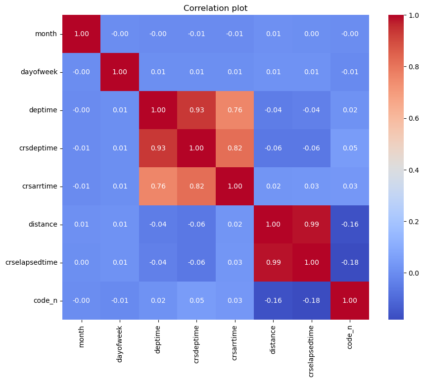

```python
selected_variables = ['month', 'dayofweek', 'deptime', 'crsdeptime', 'crsarrtime', 'distance', 'crselapsedtime', 'code_n']

# Creating the correlation matrix
correlation_matrix = regression_manifest_df[selected_variables].corr()

# Plotting the correlation matrix
plt.figure(figsize=(10, 8))
sns.heatmap(correlation_matrix, annot=True, cmap='coolwarm', fmt=".2f")
plt.title('Correlation plot')
plt.show()
```

It can be seen that there are some variables with high pairwise correlations, mainly distance and CRSElapsedTime which have a correlation score of 0.99, thus distance is removed from the model as it is less significant compared to CRSElapsedTime in previous iterations of running the model. Since none of the other pairwise correlation = 1, the assumption of no perfect multicollinerity is satisfied. It is also noted that the pairs with high correlation is expected where a larger flight distance would result in more scheduled time, and the arrival and departure times being highly correlated is expected as well.

### Sampling

Since the number of diverted flights is very low we want to ensure representation for the diverted flights thus we will use a stratified split method to extract a sample for our logistic regression model.

```python
# Seed set for reproducability
np.random.seed(321)

# Generate random indices for the sample data frame
sample_ratio = 0.2
X = regression_manifest_df.drop(columns=['diverted'])  #only contains independent variables
y = regression_manifest_df['diverted']  # only contains diverted

X_train, X_test, y_train, y_test = train_test_split(X, y, test_size=sample_ratio, stratify=y) #strat split function

# Create a DataFrame for 20% sample
sample_manifest_df = pd.DataFrame(X_train, columns=X.columns)
sample_manifest_df['diverted'] = y_train

# checking for diverted in sample_manifest_df
print(sample_manifest_df['diverted'].value_counts())
```

```
diverted
0    41195897
1       98685
Name: count, dtype: int64
```

```python
# Formula for the logistic regression model
formula = 'diverted ~ month + dayofweek + deptime + crsdeptime + crsarrtime + crselapsedtime + code_n'

# Running the inital logistic regression
logit_model = sm.Logit.from_formula(formula, data=sample_manifest_df)
logit_model_inital = logit_model.fit()

print(logit_model_inital.summary())
```

```
Optimization terminated successfully.
         Current function value: 0.016615
         Iterations 10
                           Logit Regression Results
==============================================================================
Dep. Variable:               diverted   No. Observations:             41294582
Model:                          Logit   Df Residuals:                 41294574
Method:                           MLE   Df Model:                            7
Date:                Sat, 23 Mar 2024   Pseudo R-squ.:                 0.01179
Time:                        11:08:27   Log-Likelihood:            -6.8610e+05
converged:                       True   LL-Null:                   -6.9428e+05
Covariance Type:            nonrobust   LLR p-value:                     0.000
==================================================================================
                     coef    std err          z      P>|z|      [0.025      0.975]
----------------------------------------------------------------------------------
Intercept         -6.7550      0.016   -421.071      0.000      -6.786      -6.724
month             -0.0287      0.001    -30.853      0.000      -0.031      -0.027
dayofweek         -0.0029      0.002     -1.794      0.073      -0.006       0.000
deptime            0.0004   1.62e-05     22.132      0.000       0.000       0.000
crsdeptime        -0.0003   1.83e-05    -17.387      0.000      -0.000      -0.000
crsarrtime         0.0002    9.9e-06     15.233      0.000       0.000       0.000
crselapsedtime     0.0048   3.85e-05    125.581      0.000       0.005       0.005
code_n         -9.208e-06   6.63e-06     -1.389      0.165   -2.22e-05    3.78e-06
==================================================================================
```

The output shows DayOfWeek and Code_n (Unique carrier) are not significant with p values larger than 0.05. In R, use stepAIC from the "MASS" package to improve the model by automating the stepwise regression. The function runs the logistic regression each time removing the least significant variable to come up with the most accurate model possible.

Unfortunately this step will be done manually by removing DayOfWeek and Code_n (Unique carrier) as the model fails to converge in python.

### Improving the model

**Overall model**

```python
# finalised model
formula = 'diverted ~ month + deptime + crsdeptime + crsarrtime + crselapsedtime'

# running the final model for coeficients
logit_model = sm.Logit.from_formula(formula, data=sample_manifest_df)
logit_diverted_model = logit_model.fit()

print(logit_diverted_model.summary())
```

```
Optimization terminated successfully.
         Current function value: 0.016615
         Iterations 10
                           Logit Regression Results
==============================================================================
Dep. Variable:               diverted   No. Observations:             41294582
Model:                          Logit   Df Residuals:                 41294576
Method:                           MLE   Df Model:                            5
Date:                Sat, 23 Mar 2024   Pseudo R-squ.:                 0.01178
Time:                        11:11:01   Log-Likelihood:            -6.8610e+05
converged:                       True   LL-Null:                   -6.9428e+05
Covariance Type:            nonrobust   LLR p-value:                     0.000
==================================================================================
                     coef    std err          z      P>|z|      [0.025      0.975]
----------------------------------------------------------------------------------
Intercept         -6.7746      0.013   -502.131      0.000      -6.801      -6.748
month             -0.0287      0.001    -30.848      0.000      -0.031      -0.027
deptime            0.0004   1.61e-05     22.385      0.000       0.000       0.000
crsdeptime        -0.0003   1.82e-05    -17.607      0.000      -0.000      -0.000
crsarrtime         0.0002    9.9e-06     15.230      0.000       0.000       0.000
crselapsedtime     0.0048   3.81e-05    127.083      0.000       0.005       0.005
==================================================================================
```

After removing DayOfWeek and Code_n (Unique carrier), all features are now highly significant.

**Ranking regressor/ features based on coefficient significance.**  
Looking at the output of “logit_diverted_model”, a larger absolute Z value implies a more significant regressor/ feature. From the most significant feature to the least, we have: CRSElapsedTime (127.083), Month (-30.848), DepTime (22.385), CRSDepTime (-17.607), CRSArrTime(15.230). From this it can be implied that a smaller scheduled elapsed time would result in a lower probability of diversions, which could also imply that shorter flights tend to divert less.

### Implementing the model on the full dataset

**Predicting Diverted flights using model**

```python
# Gives the predicted probabilities/ fitted values of the logistic regression for each flight
logit_diverted_predict = logit_diverted_model.predict(regression_manifest_df)

print(logit_diverted_predict)
```

```
0           0.002039
1           0.002038
2           0.001983
3           0.001985
4           0.001983
              ...
52673421    0.003250
52673422    0.003164
52673423    0.003146
52673424    0.003169
52673425    0.003135
Length: 51618228, dtype: float64
```

### Misclassification Error & Accuracy- Testing Data

```python
## Includes the fitted values into "regression_manifest_df" so that we can test accuracy and plot graphs
regression_manifest_df['probability'] = logit_diverted_predict
regression_manifest_df['predict_diverted'] = np.where(logit_diverted_predict >= 0.5, 1, 0) # Decides if the prediction is diverted or not

# Create a confusion matrix and accuracy to validate model
confusion_matrix = pd.crosstab(index=regression_manifest_df['predict_diverted'], columns=regression_manifest_df['diverted'])
accuracy = np.mean(regression_manifest_df['predict_diverted'] == regression_manifest_df['diverted'])
print("Model Accuracy:", accuracy)
print("Confusion Matrix:")
print(confusion_matrix)
```

```
Model Accuracy: 0.9976102240472106
Confusion Matrix:
diverted                 0       1
predict_diverted
0                 51494867  123351
1                        5       5
```

The model accuracy of 99.7% is considered very good but there is the worry of over fitting the model. It can be seen that the model is able to predict true non-diverted flights well but not very well for true diverted flights.

### Plotting for Overall probability against all 5 retained regressors in logit_diverted_model

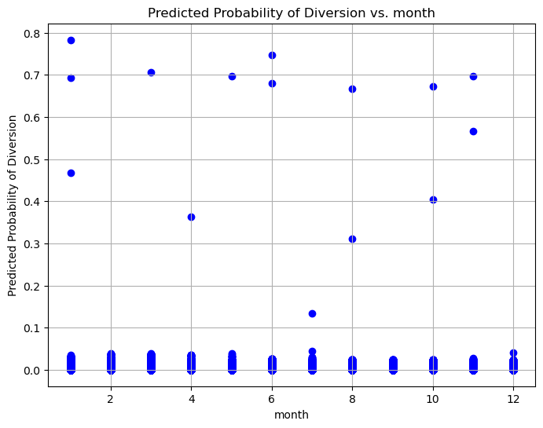

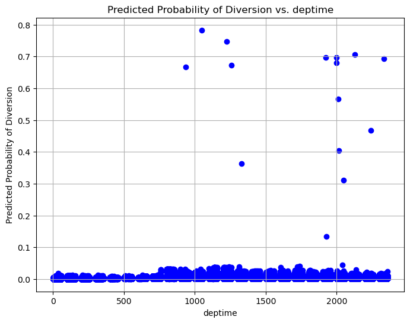

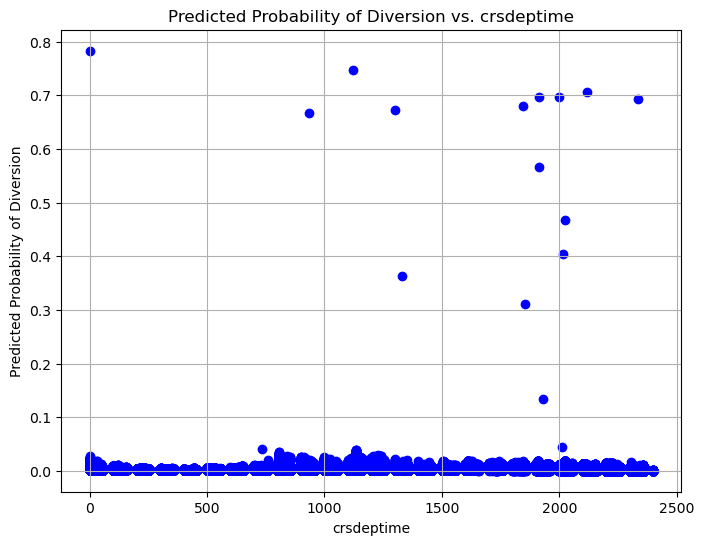

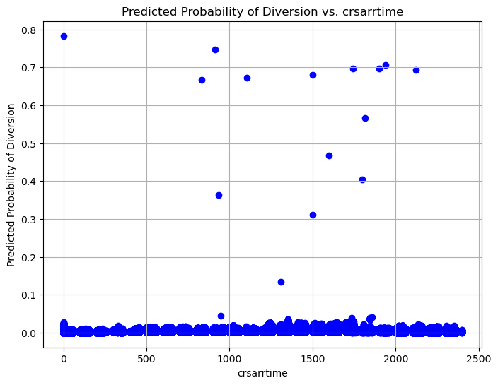

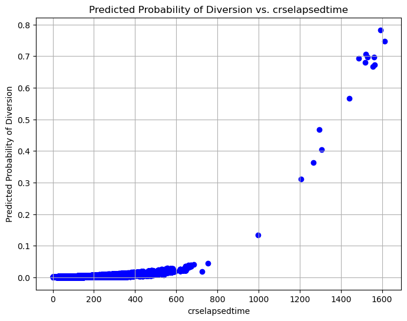

```python
independent_variables = ['month', 'deptime', 'crsdeptime', 'crsarrtime', 'crselapsedtime']

# Create probability - independent variable scatterplot
for variable in independent_variables:
    plt.figure(figsize=(8, 6))
    plt.scatter(regression_manifest_df[variable], regression_manifest_df['probability'], color='blue')
    plt.title(f'Predicted Probability of Diversion vs. {variable}')
    plt.xlabel(variable)
    plt.ylabel('Predicted Probability of Diversion')
    plt.grid(True)
    plt.show()
```

**Departure Time**  
As the departure times increase, the predicted probability of diversion also increases. This means that the model predicts that diverted flights tend to happen for frequently later into the day.

**Scheduled Arrival Time**  
As the scheduled arrival times increase, the predicted probability of diversion also increases. This means that the model predicts that diverted flights tend to happen for frequently when the flight is scheduled to land later into the day. The model predicts that most diverted flights are scheduled to land from 0700 to 2100. It is noted that there is one outlier where the flight is predicted to be diverted and it is scheduled to land around midnight.  
The scheduled arrival and departure predictions seem to have a very similar prediction, indicating that scheduled arrival times and departeure times are highly correlated.

**Scheduled Elapsed Time**  
The scheduled elapsed time shows an upward trend in diversion probabilty, where the longer the scheduled flight, the higher the probabilty of diversion. With all the predicted diverted flights having a scheduled elapsed time of 1400 minutes and above. This implies that the model is likely to predict that a flight is diverted if the longer the scheduled elapsed time.

### Plotting the yearly mean probabilities

```python
# Setting up the data frame to plot
yearly_mean_probabilities = regression_manifest_df.groupby('year')['probability'].mean().reset_index()
yearly_mean_probabilities['year'] = pd.Categorical(yearly_mean_probabilities['year'])
yearly_mean_probabilities = yearly_mean_probabilities.rename(columns = {'probability':'mean_probability'})

print(yearly_mean_probabilities.head())
```

```
   year  mean_probability
0  1990          0.002284
1  1991          0.002313
2  1992          0.002324
3  1993          0.002339
4  1994          0.002332
```

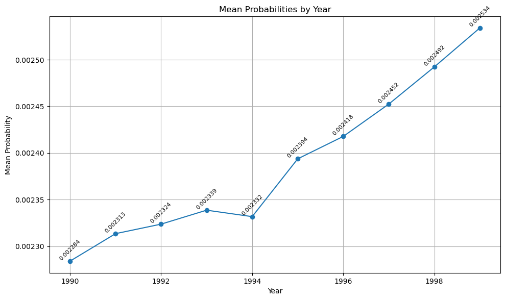

```python
plt.figure(figsize=(10, 6))
plt.plot(yearly_mean_probabilities['year'], yearly_mean_probabilities['mean_probability'], marker='o', linestyle='-')
plt.title('Mean Probabilities by Year')
plt.xlabel('Year')
plt.ylabel('Mean Probability')
plt.grid(True)

# Labeling each point
for x, y, label in zip(yearly_mean_probabilities['year'], yearly_mean_probabilities['mean_probability'], yearly_mean_probabilities['mean_probability']):
    plt.text(x, y, '{:.6f}'.format(label), va='bottom', ha='center', rotation=45, fontsize=8)

plt.tight_layout()
plt.show()
```

### Running the logit model for every year and storing the coefficents of regressors

```python
#splitting the data frame by year
yearly_manifest_df = [group for _, group in regression_manifest_df.groupby('year')]
```

```python
# Create empty data frame to store coefficients for logistic regression done for each year (10 sets total to be obtained)
coefficients_list = []

# Loop through each yearly data frame
for yearly_df in yearly_manifest_df:
    # Using finalised model
    formula = 'diverted ~ month + deptime + crsdeptime + crsarrtime + crselapsedtime'
    logit_model = sm.Logit.from_formula(formula, data=yearly_df)
    logit_result = logit_model.fit()

    # Extract coefficients
    coefficients = logit_result.params.to_dict()
    coefficients["year"] = yearly_df['year'].iloc[0]  # Extract the year from the data frame

    # Append coefficients to the list
    coefficients_list.append(coefficients)

# convertes data frame from the list
coefficients_df = pd.DataFrame(coefficients_list)

print(coefficients_df)
```

```
Optimization terminated successfully.
         Current function value: 0.020371
         Iterations 10
Optimization terminated successfully.
         Current function value: 0.017101
         Iterations 10
Optimization terminated successfully.
         Current function value: 0.015739
         Iterations 10
Optimization terminated successfully.
         Current function value: 0.014463
         Iterations 10
Optimization terminated successfully.
         Current function value: 0.016279
         Iterations 10
Optimization terminated successfully.
         Current function value: 0.013940
         Iterations 10
Optimization terminated successfully.
         Current function value: 0.018093
         Iterations 10
Optimization terminated successfully.
         Current function value: 0.015543
         Iterations 10
Optimization terminated successfully.
         Current function value: 0.016944
         Iterations 10
Optimization terminated successfully.
         Current function value: 0.016752
         Iterations 10
   Intercept     month   deptime  crsdeptime  crsarrtime  crselapsedtime  year
0  -6.361163 -0.007376  0.002290   -0.002190   -0.000046        0.004277  1990
1  -6.417199 -0.040217  0.002000   -0.001926   -0.000042        0.004915  1991
2  -6.750481 -0.002766  0.002325   -0.002219   -0.000077        0.004930  1992
3  -6.481405 -0.054496  0.002204   -0.002211   -0.000017        0.005001  1993
4  -6.441224 -0.055759  0.003525   -0.003517    0.000017        0.005168  1994
5  -6.992058 -0.017063  0.000053    0.000104    0.000027        0.004706  1995
6  -6.775512 -0.015860  0.000127   -0.000082    0.000157        0.004860  1996
7  -7.070498 -0.022625  0.000040   -0.000053    0.000315        0.004771  1997
8  -7.254354 -0.013478  0.000164   -0.000096    0.000265        0.005915  1998
9  -6.707812 -0.062210 -0.000222    0.000147    0.000389        0.004307  1999
```

### Plotting the regressor coefficient across the 10 years

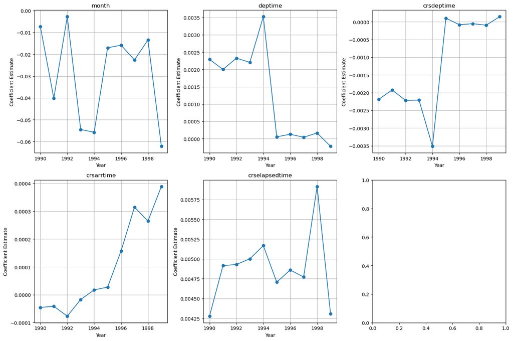

```python
# similar to yearly delay by day figure in part 2aii
fig, axes = plt.subplots(2, 3, figsize=(15, 10))
axes = axes.flatten()

# Loop through each independent variable
for i, variable in enumerate(independent_variables):
    # Plot the coefficient for the current independent variable
    ax = axes[i]
    ax.plot(coefficients_df['year'], coefficients_df[variable], marker='o', linestyle='-')
    ax.set_title(variable)
    ax.set_xlabel('Year')
    ax.set_ylabel('Coefficient Estimate')
    ax.grid(True)

plt.tight_layout()
plt.show()
```

**Month (ordinal)**  
Since the overall coefficients are negative, this means deeper into the year, the probability of diversion reduces. It is also noted that years 1993, 1994 and 1999, saw the coefficient estimate fall the lowest at to a value of -0.05 to -0.06. This implies that for these years the month has a larger influence on diversion probability.

**Scheduled Arrival Time (continuous)**  
Mostly positive coefficients estimates imply a positive relationship between scheduled arrival times and diversion probability. Seeing that the coefficient estimates grow larger over the years, this means that this feature gains influence over diversion probability throughout the decade.

**Scheduled Elapsed Time (continuous)**  
All positive coefficients estimates imply a positive relationship between scheduled elapsed times and diversion probability. 1998 had the largest coefficient estimate value implying that CRSElapsedTime had more influence over diversion probability compared to the other years with 1990 and 1999 showing the smallest amount of influence.

**Overall thoughts on the model**  
While the model is not very good in predicting diverted flights, it is good at predicting non diverted flights. The model may be improved by including dummy variables for unique carriers, origin airport and destination airport. However this approach would require a lot of memory from a computer as the unique variables would be up to almost 8000 as there are more than 3000 unique airports and more than 1000 unique carriers. Another way to improve the accuracy of the model is to have more diverted flights to train the model as a diversion rate of 0.23% might be too low to train the model adequately.